# Text Mining using TidyText

Text mining is a process of discovering new and latent features within a body of text. It uses Natural Language Processing (NLP) to enable computers to digest human language. It has many uses in the real world. A couple of examples including:

- Spam Filtering
- Sentiment Analysis
- Fraud Detection
- Knowledge Management

In this post, we will use the package `tidytext`, which is part of the `tidyverse`. You can read more about it [here](https://www.tidyverse.org/). `tidytext` is a package that uses tidy data principles to wrangle and visualize text data. In this post, we will process some text and maybe discover new information. First, make sure you have the following libraries installed, `tidytext`, `dplyr`, `ggplot2`,`stringi`, `textclean`, and `forcats`.

```r
wp_content <- page_content("en","wikipedia", page_name = "Aaron Halfaker")
```

We can gather data by mining text from Wikipedia. Let’s import nine articles with topics of math, sports, and fantasy books. This will be important later when we try to perform text analytics. We will use the function `readLines` to directly connect to a Wikipedia URL and read all text lines.

```r
wiki <- "http://en.wikipedia.org/wiki/"
titles <- c("Integral", "Derivative",
    "Calculus", "Football", "Soccer", "Basketball",
    "A_Song_of_Ice_and_Fire", "The_Lord_of_the_Rings", "His_Dark_Materials")
articles <- character(length(titles))

for (i in 1:length(titles)) {
    articles[i] <- stri_flatten(readLines(stri_paste(wiki, titles[i]), warn = F), col = " ")
}
length(articles)
```

```
[1] 9
```

Now that we have imported our articles, which we will now call documents. We can see that it is a character vector with the length of 9. This meansthat all of the text has been imported as a single cell within a vector. We need to separate each word out from the documents to be able to count them. We use a process called *tokenization*. While a computer will read strings as a series of character, humans will read it as a sentence of words. To reproduce this for computers, we can split the string using a space delimiter, `" "`, and then splitting the sentence into words or tokens. Let’s take a look at an example from one of our documents.

```r
text <- c('A Song of Ice and Fire is a series of epic fantasy novels by the American novelist and screenwriter George R. R. Martin. He began the first volume of the series, A Game of Thrones, in 1991, and it was published in 1996.')
text
```

```
[1] "A Song of Ice and Fire is a series of epic fantasy novels by the American novelist and screenwriter George R. R. Martin. He began the first volume of the series, A Game of Thrones, in 1991, and it was published in 1996."
```

We can can use the following code to tokenize this text.

```r
tokenize_text <- (unlist(lapply(text, function (x) strsplit(x, split = ' ' )))) #' '  is used as the space delimiter
tokenize_text
```

```
 [1] "A"            "Song"         "of"           "Ice"          "and"          "Fire"         "is"
 [8] "a"            "series"       "of"           "epic"         "fantasy"      "novels"       "by"
[15] "the"          "American"     "novelist"     "and"          "screenwriter" "George"       "R."
[22] "R."           "Martin."      "He"           "began"        "the"          "first"        "volume"
[29] "of"           "the"          "series,"      "A"            "Game"         "of"           "Thrones,"
[36] "in"           "1991,"        "and"          "it"           "was"          "published"    "in"
[43] "1996."
```

Fortunately, tokenization is built into the `tidytext` package. First, we will do some text cleaning by removing some common HTML tags with the function `replace_html()`. Then we will convert our large character vector into a data frame. We will follow this with `unnest_tokens()` to tokenize the documents.

```r
articles <-  replace_html(articles, symbol = TRUE)
articles <- data.frame('articles' = articles)
articles$titles <- titles
tokenized <- articles %>% unnest_tokens(word, articles)
head(tokenized)
```

|  | titles | word |
| --- | --- | --- |
| 1 | Integral | integral |
| 2 | Integral | wikipedia |
| 3 | Integral | document.documentelement.classname |
| 4 | Integral | client |
| 5 | Integral | js |
| 6 | Integral | rlconf |

If you haven’t noticed already, there are still some nonsense words that pertain to HTML code still. We can create a new database with additional HTML code to remove, but for now, this is okay as later we will weigh the important words more than the non-important words. Next, let’s count how many times each word appears in each document using the `count()` function.

```r
tokenized %>%
  count(titles, word, sort = TRUE) %>%
  head()
```

|  | titles | word | n |
| --- | --- | --- | --- |
| 1 | The_Lord_of_the_Rings | the | 1270 |
| 2 | A_Song_of_Ice_and_Fire | the | 1140 |
| 3 | Football | the | 997 |
| 4 | Basketball | the | 956 |
| 5 | Soccer | the | 841 |
| 6 | A_Song_of_Ice_and_Fire | of | 683 |

As you can see, the top words are “the” and “of”, which are not important for understanding the hidden features of the documents. This set of words are called *stop words*. They are commonly used words in any language, where they are unimportant for NLP, and are removed to focus on the important words. We will load the `stop_words` data and filter out these words from our data frame.

```r
data(stop_words)

tokenized <- tokenized %>%
  anti_join(stop_words) #this filters out the stop words
document_words <- tokenized %>%
  count(titles, word, sort = TRUE)
head(document_words)
```

|  | titles | word | n |
| --- | --- | --- | --- |
| 1 | Football | football | 540 |
| 2 | A_Song_of_Ice_and_Fire | 93 | 470 |
| 3 | Basketball | basketball | 339 |
| 4 | Soccer | football | 273 |
| 5 | A_Song_of_Ice_and_Fire | martin | 251 |
| 6 | A_Song_of_Ice_and_Fire | 2012 | 237 |

Now we can see important words that make sense for each of our documents, like the word *football* appearing the most for the Wikipedia article “Football”. Let’s take a look at a list of the most common words in “Football”.

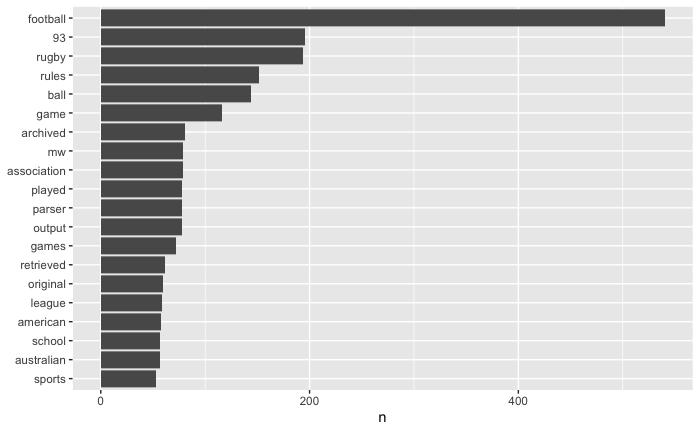

```r
document_words[document_words$titles == 'Football',] %>%
  filter(n > 50) %>%
  mutate(word = reorder(word, n)) %>%
  ggplot(aes(n, word)) +
  geom_col() +
  labs(y = NULL)
```

Let’s try to contextualize this data by ranking them based on how often they appear within the document, instead of looking at the absolute count. This is called *term frequency* (TF) and it gives the frequency of the word in each document. The TF is defined as $tf(t,d)$:
$$tf(t,d) = \frac{f_{t,d}}{\Sigma_{k}f_{t,d}}$$
where $f_{t,d}$ is the raw count of each term. In addition, each document will have its own TF. Let’s calculate it by finding the total number of words that appears per document.

```r
total_words <- document_words %>%
  group_by(titles) %>%
  summarize(total = sum(n))

document_words <- left_join(document_words, total_words)
head(document_words)
```

|  | titles | word | n | total |
| --- | --- | --- | --- | --- |
| 1 | Football | football | 540 | 11351 |
| 2 | A_Song_of_Ice_and_Fire | 93 | 470 | 12536 |
| 3 | Basketball | basketball | 339 | 11086 |
| 4 | Soccer | football | 273 | 9370 |
| 5 | A_Song_of_Ice_and_Fire | martin | 251 | 12536 |
| 6 | A_Song_of_Ice_and_Fire | 2012 | 237 | 12536 |

Now we can rank each word by dividing the raw count of the word by the total number of words in the document.

```r
freq_by_rank <- document_words %>%
  group_by(titles) %>%
  mutate(rank = row_number(),
         `term frequency` = n/total) %>%
  ungroup()
head(freq_by_rank)
```

| titles | word | n | total | rank | term frequency |
| --- | --- | --- | --- | --- | --- |
| Football | football | 540 | 11351 | 1 | 0.04757290 |
| A_Song_of_Ice_and_Fire | 93 | 470 | 12536 | 1 | 0.03749202 |
| Basketball | basketball | 339 | 11086 | 1 | 0.03057911 |
| Soccer | football | 273 | 9370 | 1 | 0.02913554 |
| A_Song_of_Ice_and_Fire | martin | 251 | 12536 | 2 | 0.02002234 |
| A_Song_of_Ice_and_Fire | 2012 | 237 | 12536 | 3 | 0.01890555 |

```r
document_tf_idf <- document_words %>%
  bind_tf_idf(word, titles, n)
head(document_tf_idf)
```

|  | titles | word | n | total | tf | idf | tf_idf |
| --- | --- | --- | --- | --- | --- | --- | --- |
| 1 | Football | football | 540 | 11351 | 0.04757290 | 1.0986123 | 0.052264174 |
| 2 | A_Song_of_Ice_and_Fire | 93 | 470 | 12536 | 0.03749202 | 0.0000000 | 0.000000000 |
| 3 | Basketball | basketball | 339 | 11086 | 0.03057911 | 1.0986123 | 0.033594585 |
| 4 | Soccer | football | 273 | 9370 | 0.02913554 | 1.0986123 | 0.032008661 |
| 5 | A_Song_of_Ice_and_Fire | martin | 251 | 12536 | 0.02002234 | 0.8109302 | 0.016236717 |
| 6 | A_Song_of_Ice_and_Fire | 2012 | 237 | 12536 | 0.01890555 | 0.1177830 | 0.002226753 |

We can see that the word `93` in `A_Song_of_Ice_and_Fire` had a very high *term frequency*. However, when we weight it to produce the TF_IDF score, it is reduced to a value of 0. Now let’s take a look at the top 5 words per document.

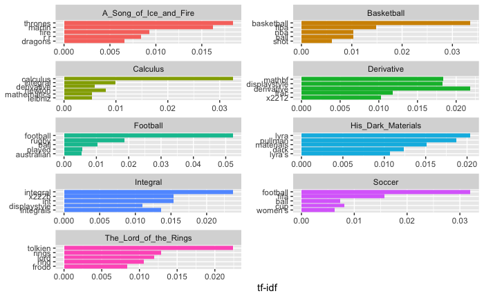

```r
library(forcats)

document_tf_idf %>%
  group_by(titles) %>%
  slice_max(tf_idf, n = 5) %>%
  ungroup() %>%
  ggplot(aes(tf_idf, fct_reorder(word, tf_idf), fill = titles)) +
  geom_col(show.legend = FALSE) +
  facet_wrap(~titles, ncol = 2, scales = "free") +
  labs(x = "tf-idf", y = NULL)
```

For the most part, the top words weighted using TF-IDF makes sense. Now that we have set up our data, we can start digging in deeper to find some relationships between the documents. We will take a look at *Latent Semantic Analysis* (LSA). It is a NLP technique that analyzes a set of documents and the terms within to find common or divergent concepts related to the documents and terms. We can extend this definition of LSA to be used as a method for classifying documents into different topics. To start, we need to convert our data into a term-document matrix, where the columns corresponds to documents and the rows correspond to terms. Document-term matrix is the transpose version.

```r
tf_idf_matrix <- document_tf_idf %>% select(titles, word, tf_idf)%>% pivot_wider(names_from = titles, values_from = tf_idf, values_fill = 0) %>% as.data.frame()
words <- tf_idf_matrix[[1]]
tf_idf_matrix <- tf_idf_matrix[,-1] #Removing the column containing the words
rownames(tf_idf_matrix) <- words
```

LSA is a dimensional reduction technique similar to PCA. In fact, to perform it, we calculate the singular value decomposition (SVD) on the document-term matrix. See my other post to learn more about SVD.

$$M = U \Sigma V^{T}$$
By using LSA, we will reduce our high-dimensional data into lower dimensional data to do one of three things:

- Reduce the data to save on computational work.
- De-noise the data by weighting the more important terms.
- Decrease the sparsity of the matrix by relating synonyms. This means that some dimensions become merged due to related terms. In addition, the effects of words with multiple means are mitigated.

```r
top_words <- document_tf_idf %>%
    group_by(titles) %>%
    slice_max(tf_idf, n = 25) %>% pull(word) %>% unique()
```

We perform LSA by passing our term-document matrix into the function`svd()`.

```r
LSA <- svd(tf_idf_matrix[top_words,], 4)
rownames(LSA$u) <- rownames(tf_idf_matrix[top_words,])
rownames(LSA$v) <- colnames(tf_idf_matrix[top_words,])
colnames(LSA$v) <- paste0('LSA_', c(1:dim(LSA$v)[2]))
colnames(LSA$u) <- paste0('LSA_', c(1:dim(LSA$u)[2]))
```

We take the right-singular vector $V$, which contains a set of orthonormal vectors that spans the row space of our term-document matrix. By plotting the first two columns, we should observe a separation between the documents.

[figure not shown]

```r
#install.packages("ggrepel")
library(ggrepel)

df <- LSA$v %>% as.data.frame() %>% select('LSA_1', 'LSA_2')
df$title <- rownames(df)

ggplot(df, aes(x = LSA_1, y = LSA_2, color = title )) +
  geom_text_repel(aes(label = title), color = 'black') +
  coord_fixed()
```

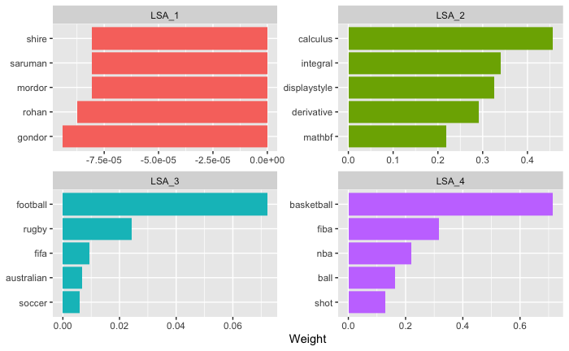

```r
df <- LSA$u %>% as.data.frame()
df$word <- rownames(df)
df <- df %>% pivot_longer(cols = c(colnames(LSA$u)))

df %>%
  group_by(name) %>%
  slice_max(value, n = 5) %>%
  ungroup() %>%
  ggplot(aes(value, fct_reorder(word, value), fill = name)) +
  geom_col(show.legend = FALSE) +
  facet_wrap(~name, ncol = 2, scales = "free") +
  labs(x = "Weight", y = NULL)
```

`LSA_1` has words related to fantasy, while `LSA_2` has words related to math. We can see that `LSA_3` and `LSA_4` are comprised of football- and basketball-related terms and this may give reason to why the documents did not cluster as closely in the first two dimensions. Let’s make the same graph with `LSA_3` and `LSA_4`. We should observe a clear separation between these two topics.

[figure not shown]

```r
df <- LSA$v %>% as.data.frame() %>% select('LSA_3', 'LSA_4')
df$title <- rownames(df)

ggplot(df, aes(x = LSA_3, y = LSA_4, color = title )) +
  geom_text_repel(aes(label = title), color = 'black') +
  coord_fixed()
```

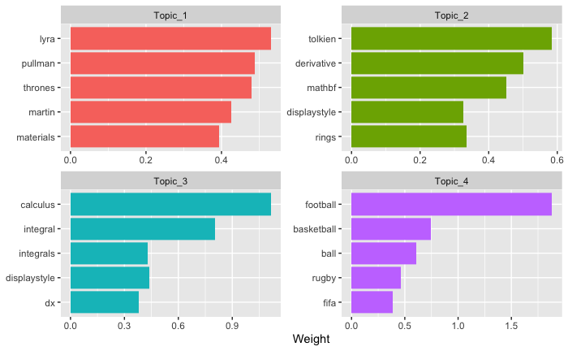

```r
df <- basis(nmf_results) %>% as.data.frame()
colnames(df) <- paste0('Topic_', c(1:dim(df)[2]))
topics <- colnames(df)
df$word <- rownames(df)

df <- df %>% pivot_longer(cols = c(topics))

df %>%
  group_by(name) %>%
  slice_max(value, n = 5) %>%
  ungroup() %>%
  ggplot(aes(value, fct_reorder(word, value), fill = name)) +
  geom_col(show.legend = FALSE) +
  facet_wrap(~name, ncol = 2, scales = "free") +
  labs(x = "Weight", y = NULL)
```

[output not shown]

Here we see a slightly different result. We first dimension `Topic_1` is composed of terms related to His_Dark_Materials" and A_Song_of_Ice_and_Fire“, but not”The_Lord_of_the_Rings“. On the other hand, `Topic_2` contains terms related to both”The_Lord_of_the_Rings" and “Derivative”. While weird, it is not inexplicable. We chose the number of topics or factorization rank *a priori* and it may not have been the most optimal number. Too high a number, we risk overfitting, while too low of a number will provide a bad representation of the data. There are several techniques that we can use to find the optimal value that we won’t dig into here.

https://www.tidytextmining.com/index.html

https://mccormickml.com/2016/03/25/lsa-for-text-classification-tutorial/#:~:text=Latent%20Semantic%20Analysis%20takes%20tf%2Didf%20one%20step%20further.&text=LSA%20is%20quite%20simple%2C%20you,Machine%20Learning%20course%20on%20Coursera.

https://towardsdatascience.com/topic-modeling-articles-with-nmf-8c6b2a227a45

https://www.kaggle.com/elenageminiani/nmf-and-image-compression